# Homework_8

RMJ

2025-03-19

### Running the example data

For this first part we will mostly be doing an example workflow

```r
# first load libraries

library(ggplot2)
library(MASS)
library(tidyverse)
theme_set(theme_bw(base_size = 16))
```

bring in our data vector

```r
# from what I gather we are making an object z which is composed of 3000 random numbers

z <- rnorm(n=3000,mean=0.2)
z <- data.frame(1:3000,z)
names(z) <- list("ID","myVar")
z <- z[z$myVar>0,]
str(z)
```

```
## 'data.frame':    1731 obs. of  2 variables:
##  $ ID   : int  1 2 3 4 5 7 8 9 10 11 ...
##  $ myVar: num  0.4181 0.0216 0.2764 1.1487 0.1693 ...
```

```r
summary(z$myVar)
```

```
##     Min.  1st Qu.   Median     Mean  3rd Qu.     Max.
## 0.000813 0.353326 0.738302 0.863336 1.233888 3.621359
```

for distributions the best thing we can do is visualize it. we’ll do that with a general histogram but lets make it cute

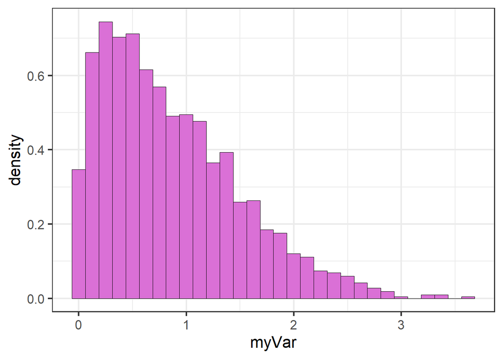

```r
# the original color was cornsilk we will not be doing that because it is ugly.

p1 <- ggplot(data=z, aes(x=myVar, y=..density..)) +
  geom_histogram(color="black",fill="orchid",size=0.2)
print(p1)
```

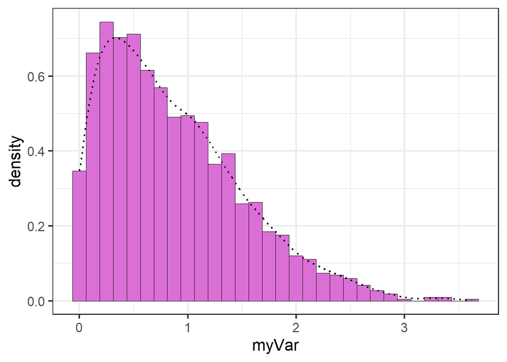

```r
# now that's a hot graph!

# now we can add a density curve so we can see the distribution

p1 <-  p1 +  geom_density(linetype="dotted",size=0.75)
print(p1)
```

so we have the shape of our distribution now we can move on to getting the maximum likelihood parameters of the normal

```r
normPars <- fitdistr(z$myVar,"normal")
print(normPars)
```

```
##       mean          sd
##   0.86333572   0.63483577
##  (0.01525854) (0.01078941)
```

```r
str(normPars)
```

```
## List of 5
##  $ estimate: Named num [1:2] 0.863 0.635
##   ..- attr(*, "names")= chr [1:2] "mean" "sd"
##  $ sd      : Named num [1:2] 0.0153 0.0108
##   ..- attr(*, "names")= chr [1:2] "mean" "sd"
##  $ vcov    : num [1:2, 1:2] 0.000233 0 0 0.000116
##   ..- attr(*, "dimnames")=List of 2
##   .. ..$ : chr [1:2] "mean" "sd"
##   .. ..$ : chr [1:2] "mean" "sd"
##  $ n       : int 1731
##  $ loglik  : num -1670
##  - attr(*, "class")= chr "fitdistr"
```

```r
normPars$estimate["mean"] # note structure of getting a named attribute
```

```
##      mean
## 0.8633357
```

Now we can overlay what is a normal probability density with our data

```r
meanML <- normPars$estimate["mean"]
sdML <- normPars$estimate["sd"]

xval <- seq(0,max(z$myVar),len=length(z$myVar))

 stat <- stat_function(aes(x = xval, y = ..y..), fun = dnorm, colour="Dark Cyan", n = length(z$myVar), args = list(mean = meanML, sd = sdML))
 p1 + stat
```

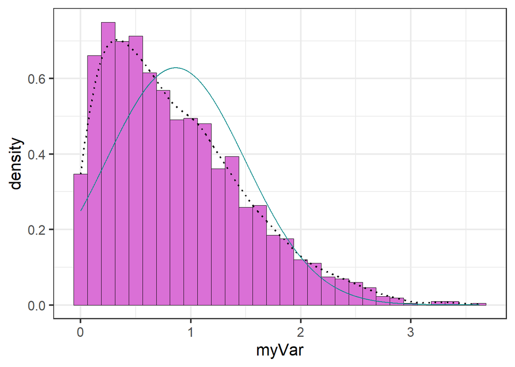

looks like we got a bit of a skew!

We’ll run through each distribution to see how it fits

Exponential

```r
expoPars <- fitdistr(z$myVar,"exponential")
rateML <- expoPars$estimate["rate"]

stat2 <- stat_function(aes(x = xval, y = ..y..), fun = dexp, colour="gold", n = length(z$myVar), args = list(rate=rateML))
 p1 + stat + stat2
```

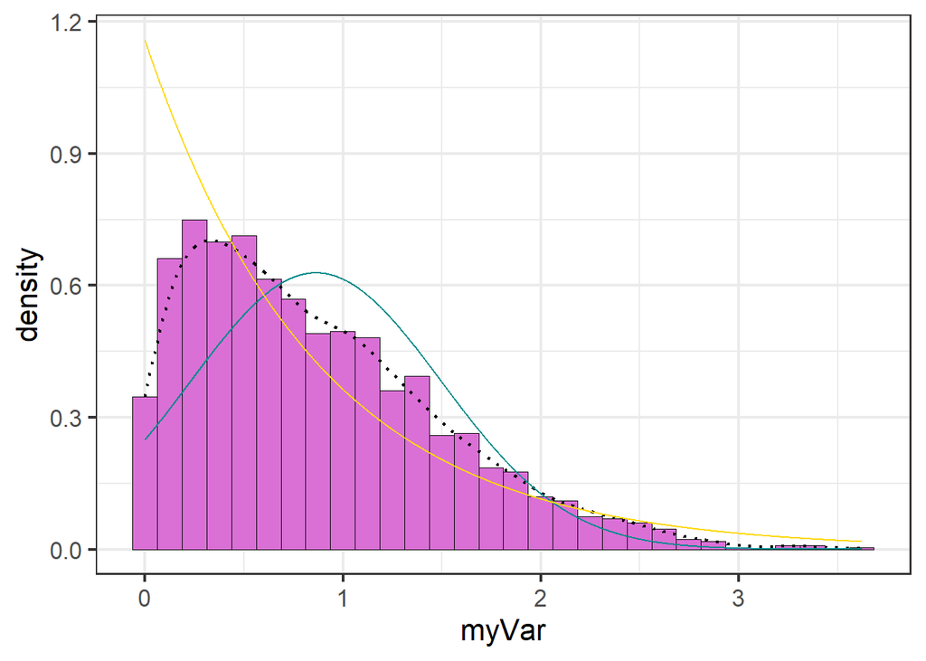

Uniform

```r
stat3 <- stat_function(aes(x = xval, y = ..y..), fun = dunif, colour="darkgreen", n = length(z$myVar), args = list(min=min(z$myVar), max=max(z$myVar)))
 p1 + stat + stat2 + stat3
```

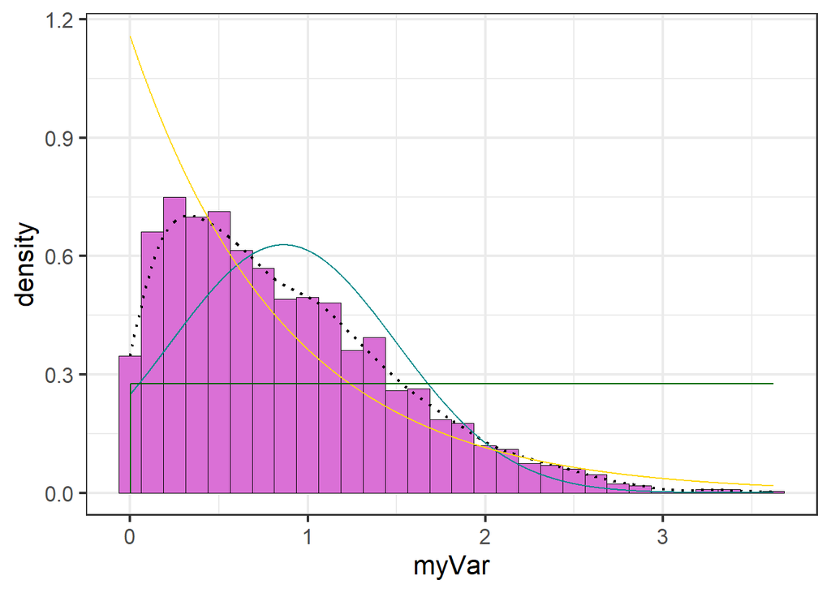

uniform definitely ain’t it

Gamma

```r
gammaPars <- fitdistr(z$myVar,"gamma")
shapeML <- gammaPars$estimate["shape"]
rateML <- gammaPars$estimate["rate"]

stat4 <- stat_function(aes(x = xval, y = ..y..), fun = dgamma, colour="Tomato", n = length(z$myVar), args = list(shape=shapeML, rate=rateML))
 p1 + stat + stat2 + stat3 + stat4
```

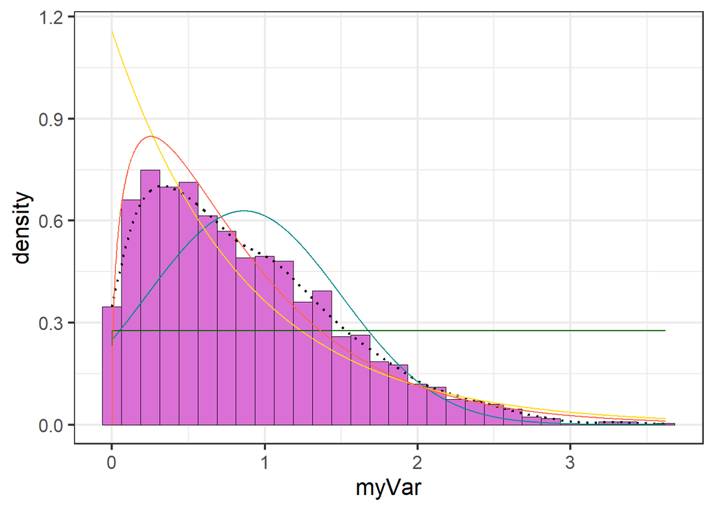

Beta

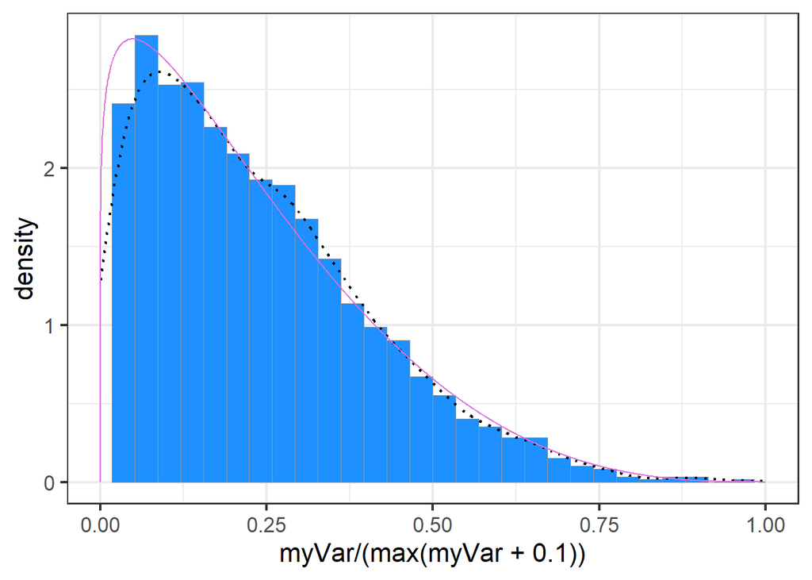

```r
pSpecial <- ggplot(data=z, aes(x=myVar/(max(myVar + 0.1)), y=..density..)) +
  geom_histogram(color="grey60",fill="dodgerblue",size=0.2) +
  xlim(c(0,1)) +
  geom_density(size=0.75,linetype="dotted")

betaPars <- fitdistr(x=z$myVar/max(z$myVar + 0.1),start=list(shape1=1,shape2=2),"beta")
shape1ML <- betaPars$estimate["shape1"]
shape2ML <- betaPars$estimate["shape2"]

statSpecial <- stat_function(aes(x = xval, y = ..y..), fun = dbeta, colour="orchid", n = length(z$myVar), args = list(shape1=shape1ML,shape2=shape2ML))
pSpecial + statSpecial
```